# IMDB - Exploratory Data Analysis

For this assignment, we are using the IMDB dataset. IMDB is one of the biggest movie rating websites in the world. The website stored almost every movie that has ever been released or that is on the planning to be released. The website stored more than 6 million titles with different types of information: movie director, movie cast, ratings, ratings, etc. IMDB is owned by Amazon since 1998.

```r
library(tidyverse)
library(dlookr)
IMDB <- read_csv("data/IMDB.csv")
str(IMDB)
```

```
## tibble [4,000 x 28] (S3: spec_tbl_df/tbl_df/tbl/data.frame)
##  $ color                    : chr [1:4000] "Color" "Color" "Color" "Color" ...
##  $ director_name            : chr [1:4000] "Richard LaGravenese" "Malcolm D. Lee" "Danny Leiner" NA ...
##  $ num_critic_for_reviews   : num [1:4000] 131 81 106 9 144 139 51 97 157 99 ...
##  $ duration                 : num [1:4000] 126 86 83 60 89 98 88 94 115 120 ...
##  $ director_facebook_likes  : num [1:4000] 98 92 8 NA 406 235 6 32 0 11 ...
##  $ actor_3_facebook_likes   : num [1:4000] 37 466 612 460 759 229 854 453 35 NA ...
##  $ actor_2_name             : chr [1:4000] "Harry Connick Jr." "Eddie Griffin" "Mary Lynn Rajskub" "Philip Winchester" ...
##  $ actor_1_facebook_likes   : num [1:4000] 18000 744 3000 666 989 4000 2000 1000 85 16 ...
##  $ gross                    : num [1:4000] 53680848 38230435 46729374 NA 10824921 ...
##  $ genres                   : chr [1:4000] "Drama|Romance" "Action|Comedy" "Comedy|Mystery" "Action|Crime|Drama|Thriller" ...
##  $ actor_1_name             : chr [1:4000] "Gerard Butler" "Dave Chappelle" "Jennifer Garner" "Nick Wechsler" ...
##  $ movie_title              : chr [1:4000] "P.S. I Love You " "Undercover Brother " "Dude, Where's My Car? " "The Player " ...
##  $ num_voted_users          : num [1:4000] 167967 29661 116625 5817 200293 ...
##  $ cast_total_facebook_likes: num [1:4000] 18726 3001 6454 4043 3462 ...
##  $ actor_3_name             : chr [1:4000] "Nellie McKay" "Chi McBride" "Marla Sokoloff" "Jeff Marlow" ...
##  $ facenumber_in_poster     : num [1:4000] 1 3 2 2 0 1 1 4 0 0 ...
##  $ plot_keywords            : chr [1:4000] "birthday|friendship|hairy chest|letter|widow" "african american|cadillac|disguise|secret agent|undercover" "bare chested male|gay kiss|homoeroticism|lesbian kiss|transsexual" "bet|friend|pit boss|secret|surveillance" ...
##  $ movie_imdb_link          : chr [1:4000] "http://www.imdb.com/title/tt0431308/?ref_=fn_tt_tt_1" "http://www.imdb.com/title/tt0279493/?ref_=fn_tt_tt_1" "http://www.imdb.com/title/tt0242423/?ref_=fn_tt_tt_1" "http://www.imdb.com/title/tt4474310/?ref_=fn_tt_tt_1" ...
##  $ num_user_for_reviews     : num [1:4000] 243 179 469 25 621 385 54 71 361 230 ...
##  $ language                 : chr [1:4000] "English" "English" "English" "English" ...
##  $ country                  : chr [1:4000] "USA" "USA" "USA" "USA" ...
##  $ content_rating           : chr [1:4000] "PG-13" "PG-13" "PG-13" "TV-14" ...
##  $ budget                   : num [1:4000] 30000000 25000000 13000000 NA 10000000 10000000 70000000 28000000 2000000 2280000 ...
##  $ title_year               : num [1:4000] 2007 2002 2000 NA 1999 ...
##  $ actor_2_facebook_likes   : num [1:4000] 631 489 934 579 939 464 1000 626 79 0 ...
##  $ imdb_score               : num [1:4000] 7.1 5.8 5.5 7.1 7.8 5.9 5.6 5.4 8.1 7.8 ...
##  $ aspect_ratio             : num [1:4000] 1.85 1.85 1.37 16 1.85 1.85 NA 1.85 1.85 1.37 ...
##  $ movie_facebook_likes     : num [1:4000] 20000 0 0 0 16000 0 5000 0 11000 3000 ...
##  - attr(*, "spec")=
##   .. cols(
##   ..   color = col_character(),
##   ..   director_name = col_character(),
##   ..   num_critic_for_reviews = col_double(),
##   ..   duration = col_double(),
##   ..   director_facebook_likes = col_double(),
##   ..   actor_3_facebook_likes = col_double(),
##   ..   actor_2_name = col_character(),
##   ..   actor_1_facebook_likes = col_double(),
##   ..   gross = col_double(),
##   ..   genres = col_character(),
##   ..   actor_1_name = col_character(),
##   ..   movie_title = col_character(),
##   ..   num_voted_users = col_double(),
##   ..   cast_total_facebook_likes = col_double(),
##   ..   actor_3_name = col_character(),
##   ..   facenumber_in_poster = col_double(),
##   ..   plot_keywords = col_character(),
##   ..   movie_imdb_link = col_character(),
##   ..   num_user_for_reviews = col_double(),
##   ..   language = col_character(),
##   ..   country = col_character(),
##   ..   content_rating = col_character(),
##   ..   budget = col_double(),
##   ..   title_year = col_double(),
##   ..   actor_2_facebook_likes = col_double(),
##   ..   imdb_score = col_double(),
##   ..   aspect_ratio = col_double(),
##   ..   movie_facebook_likes = col_double()
##   .. )
```

Missing values are frequently encountered within a big dataset. Before we analyse and visualise the data, the following script is applied for filtering out all the rows that contain at least one NA value. This to have a complete dataset that can be used for data analysis. Besides removing all the rows with NA, we will also remove the columns which we will not use for this analysis anyways.

```r
IMDB <- IMDB %>% drop_na()
IMDB <- select(IMDB, -actor_2_facebook_likes, -plot_keywords, -movie_imdb_link, -actor_1_facebook_likes, -actor_3_facebook_likes, -cast_total_facebook_likes, -facenumber_in_poster, -aspect_ratio, -director_facebook_likes, -num_user_for_reviews, -num_voted_users, -num_critic_for_reviews, -movie_facebook_likes)
IMDB[1:50,]
```

| color | director_name | duration | actor_2_name | gross | genres | actor_1_name | movie_title | actor_3_name | language | country | content_rating | budget | title_year | imdb_score |
| --- | --- | --- | --- | --- | --- | --- | --- | --- | --- | --- | --- | --- | --- | --- |
| Color | Richard LaGravenese | 126 | Harry Connick Jr. | 53680848 | Drama\|Romance | Gerard Butler | P.S. I Love You | Nellie McKay | English | USA | PG-13 | 3.00e+07 | 2007 | 7.1 |
| Color | Malcolm D. Lee | 86 | Eddie Griffin | 38230435 | Action\|Comedy | Dave Chappelle | Undercover Brother | Chi McBride | English | USA | PG-13 | 2.50e+07 | 2002 | 5.8 |
| Color | Danny Leiner | 83 | Mary Lynn Rajskub | 46729374 | Comedy\|Mystery | Jennifer Garner | Dude, Where's My Car? | Marla Sokoloff | English | USA | PG-13 | 1.30e+07 | 2000 | 5.5 |
| Color | Mike Judge | 89 | Stephen Root | 10824921 | Comedy | Gary Cole | Office Space | Diedrich Bader | English | USA | R | 1.00e+07 | 1999 | 7.8 |
| Color | Peyton Reed | 98 | Lindsay Sloane | 68353550 | Comedy\|Sport | Kirsten Dunst | Bring It On | Clare Kramer | English | USA | PG-13 | 1.00e+07 | 2000 | 5.9 |
| Color | Brian Levant | 94 | Amber Valletta | 24268828 | Action\|Comedy\|Family | Madeline Carroll | The Spy Next Door | George Lopez | English | USA | PG | 2.80e+07 | 2010 | 5.4 |
| Color | Alejandro G. Irritu | 115 | Jorge Salinas | 5383834 | Drama\|Thriller | Adriana Barraza | Amores Perros | Goya Toledo | Spanish | Mexico | R | 2.00e+06 | 2000 | 8.1 |
| Color | David Ayer | 109 | Chris Evans | 26415649 | Action\|Crime\|Drama\|Thriller | Keanu Reeves | Street Kings | Noel Gugliemi | English | USA | R | 2.00e+07 | 2008 | 6.8 |
| Color | Ang Lee | 120 | Pei-Pei Cheng | 128067808 | Action\|Drama\|Romance | Chen Chang | Crouching Tiger, Hidden Dragon | Sihung Lung | Mandarin | Taiwan | PG-13 | 1.50e+07 | 2000 | 7.9 |
| Color | Mark Herman | 94 | Sheila Hancock | 9030581 | Drama\|War | Richard Johnson | The Boy in the Striped Pajamas | Cara Horgan | English | UK | PG-13 | 1.25e+07 | 2008 | 7.8 |

[output cut: 40 more lines]

The top 10 movies based on the clean dataset is the following:

```r
IMDB %>%
    select(movie_title, director_name, imdb_score, duration, genres) %>%
    top_n(10, imdb_score) %>%
    arrange(desc(imdb_score)) %>%
    head(10)
```

| movie_title | director_name | imdb_score | duration | genres |
| --- | --- | --- | --- | --- |
| The Godfather | Francis Ford Coppola | 9.2 | 175 | Crime\|Drama |
| The Dark Knight | Christopher Nolan | 9.0 | 152 | Action\|Crime\|Drama\|Thriller |
| Pulp Fiction | Quentin Tarantino | 8.9 | 178 | Crime\|Drama |
| Schindler's List | Steven Spielberg | 8.9 | 185 | Biography\|Drama\|History |
| The Lord of the Rings: The Return of the King | Peter Jackson | 8.9 | 192 | Action\|Adventure\|Drama\|Fantasy |
| The Lord of the Rings: The Fellowship of the Ring | Peter Jackson | 8.8 | 171 | Action\|Adventure\|Drama\|Fantasy |
| Fight Club | David Fincher | 8.8 | 151 | Drama |
| Star Wars: Episode V - The Empire Strikes Back | Irvin Kershner | 8.8 | 127 | Action\|Adventure\|Fantasy\|Sci-Fi |
| Inception | Christopher Nolan | 8.8 | 148 | Action\|Adventure\|Sci-Fi\|Thriller |
| One Flew Over the Cuckoo's Nest | Milos Forman | 8.7 | 133 | Drama |

To compute the statistics of the numerical variables we are using summary():

```r
summary(IMDB)
```

```
##     color           director_name         duration     actor_2_name
##  Length:2964        Length:2964        Min.   : 37.0   Length:2964
##  Class :character   Class :character   1st Qu.: 96.0   Class :character
##  Mode  :character   Mode  :character   Median :106.0   Mode  :character
##                                        Mean   :110.2
##                                        3rd Qu.:120.0
##                                        Max.   :330.0
##      gross              genres          actor_1_name       movie_title
##  Min.   :      162   Length:2964        Length:2964        Length:2964
##  1st Qu.:  8740578   Class :character   Class :character   Class :character
##  Median : 30242898   Mode  :character   Mode  :character   Mode  :character
##  Mean   : 52776132
##  3rd Qu.: 67271408
##  Max.   :760505847
##  actor_3_name         language           country          content_rating
##  Length:2964        Length:2964        Length:2964        Length:2964
##  Class :character   Class :character   Class :character   Class :character
##  Mode  :character   Mode  :character   Mode  :character   Mode  :character
##
##
##
##      budget            title_year     imdb_score
##  Min.   :1.100e+03   Min.   :1927   Min.   :1.600
##  1st Qu.:1.000e+07   1st Qu.:1999   1st Qu.:5.900
##  Median :2.500e+07   Median :2004   Median :6.500
##  Mean   :4.379e+07   Mean   :2003   Mean   :6.452
##  3rd Qu.:5.000e+07   3rd Qu.:2010   3rd Qu.:7.200
##  Max.   :4.200e+09   Max.   :2016   Max.   :9.200
```

**Individual histograms** We are going to plot some histograms of the numerical variables from the IMDB dataset, which in this case are the Duration, Year, and the IMDB ratings.

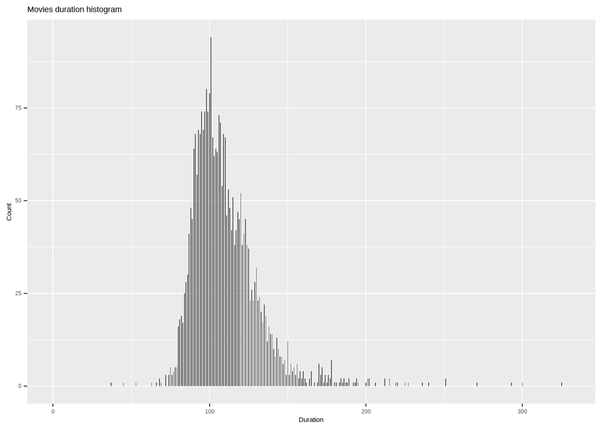

```r
ggplot(data = IMDB, aes(x = duration)) +
  geom_histogram(binwidth = 0.5) +
  xlim(c(0, quantile(IMDB$duration, 1))) +
  labs(title = "Movies duration histogram", x = "Duration", y = "Count")
```

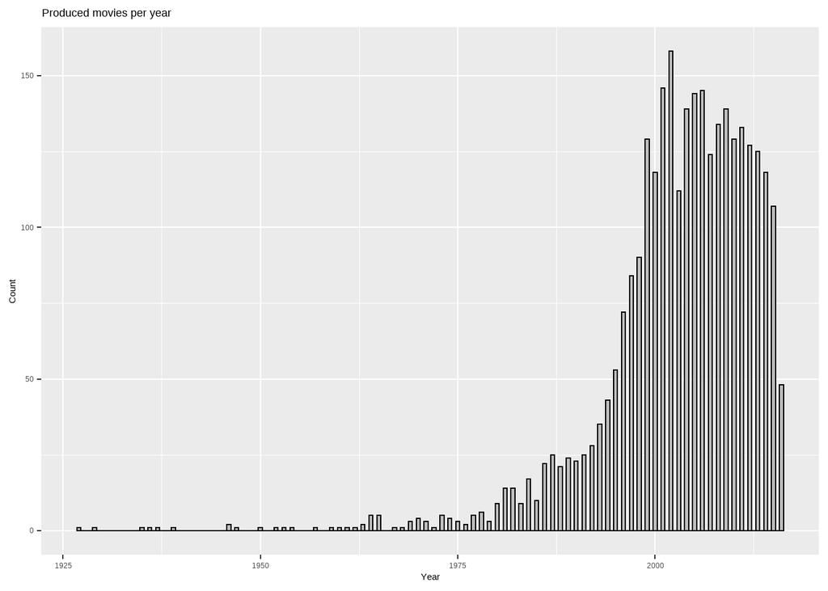

```r
ggplot(data = IMDB, aes(x = title_year)) +
  geom_histogram(binwidth = 0.5, fill = "grey", color = "black") +
  labs(title = "Produced movies per year", x = "Year", y = "Count")
```

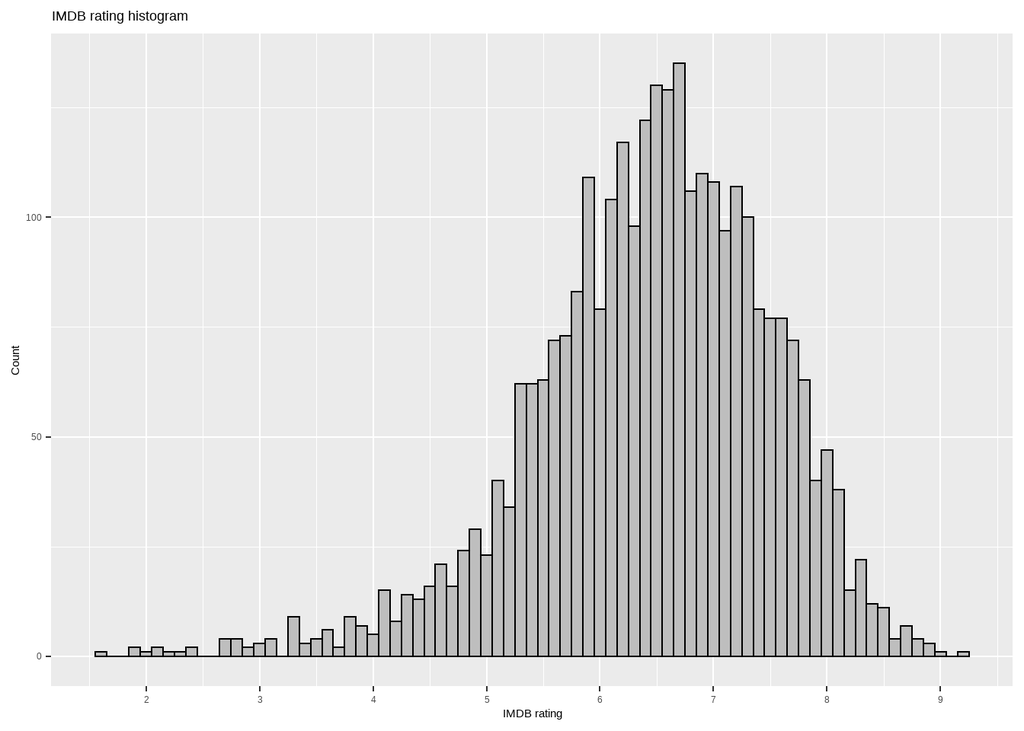

```r
ggplot(data = IMDB, aes(x = imdb_score)) +
  geom_histogram(binwidth = 0.1, fill = "grey", color = "black") +
  labs(title = "IMDB rating histogram", x = "IMDB rating", y = "Count") +
  scale_x_continuous(breaks = seq(0,10,1))
```

We can draw some conclusions from the individual histograms:

**Univariate Exploratory Data Analysis**

For the numerical values, we can plot a correlation matrix to see which variables are related to each other:

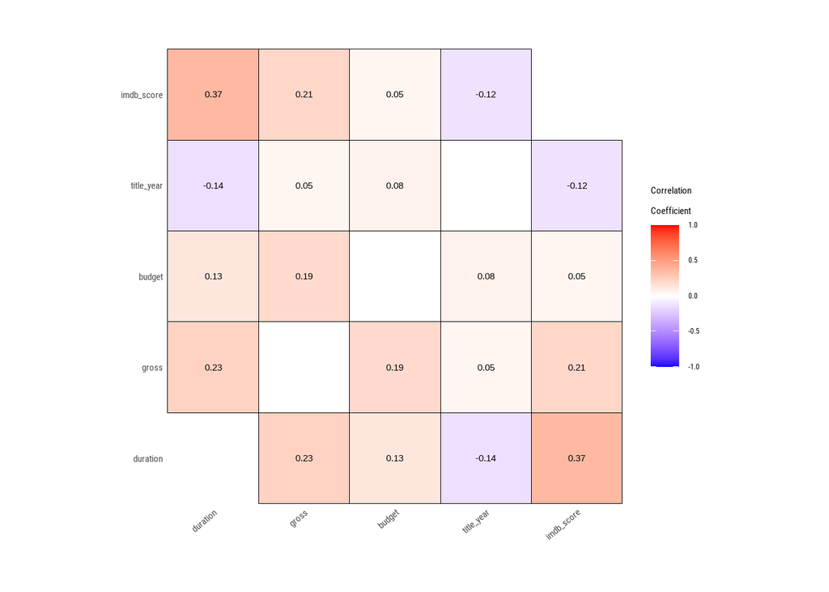

```r
plot_correlate(IMDB)
```

Based on the correlation matrix, we can notice the following items:

1. There is a relationship between the duration and the IMDB score.
2. There is no correlation between the duration and year of the movie that has been produced.
3. There is also no correlation the year and IMDB score of the movie.

To find out more about the positive correlation, we will see if movies with a longer or shorter duration have better ratings on IMDB.

[figure not shown]

```r
IMDB %>%
    group_by(movie_title) %>%
    unique() %>%
    ggplot(aes(duration, imdb_score)) +
    geom_point(alpha = 0.1, color="Red") +
    scale_y_continuous(breaks=seq(0,10,1)) +
    scale_x_continuous(breaks=seq(0,300,50)) +
        labs(title = "Scatterplot if duration has effect on the IMDB ratings", x = "Duration movies (in minutes)",
             y = "IMDB rating")
```

Are colored movies have a longer movie duration than movies which are black and white? Based on the density plot below, we notice that it is almost identical. Both are normally distributed, but the black and white movies have a slightly thicker tail on the right side related to the duration. This implies that the right tail is positively skewed. It can be derived as well that most movies around the 100-minute mark are colored.

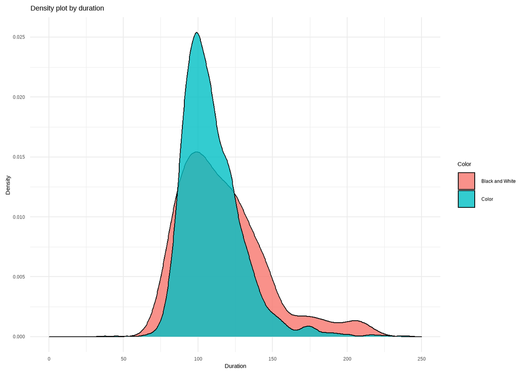

```r
ggplot(IMDB, aes(duration)) +
  geom_density(aes(fill = factor(color)), alpha = 0.8) +
  labs(title = "Density plot by duration", x = "Duration",
             y = "Density", fill = "Color") +
  theme_minimal() +
  xlim(0, 250)
```

If we want to know which countries produce the most and best movies, then we first need to filter it to the top 5 countries that produce the most movies:

```r
top_5_country <- IMDB %>%
  group_by(country) %>%
  summarise(count = n()) %>%
  top_n(5) %>%
  arrange(desc(count))
top_5_country
```

| country | count |
| --- | --- |
| USA | 2350 |
| UK | 253 |
| France | 79 |
| Germany | 69 |
| Canada | 43 |

When the countries have been filtered to the top 5 countries with the most produced movies, then we will add the variables that we need to have for the scatter plot based on the selected variables:

```r
top_5 <- IMDB %>%
  select(country, imdb_score, gross) %>%
  filter(country %in% top_5_country$country)

top_5 <- mutate(top_5, gross_divide = top_5$gross / 10000)

top_5
```

| country | imdb_score | gross | gross_divide |
| --- | --- | --- | --- |
| USA | 7.1 | 53680848 | 5368.0848 |
| USA | 5.8 | 38230435 | 3823.0435 |
| USA | 5.5 | 46729374 | 4672.9374 |
| USA | 7.8 | 10824921 | 1082.4921 |
| USA | 5.9 | 68353550 | 6835.3550 |
| USA | 5.4 | 24268828 | 2426.8828 |
| USA | 6.8 | 26415649 | 2641.5649 |
| UK | 7.8 | 9030581 | 903.0581 |
| USA | 6.5 | 20275446 | 2027.5446 |
| USA | 6.3 | 13391174 | 1339.1174 |

[output cut: 2784 more lines]

[figure not shown]

```r
ggplot(data = top_5, mapping = aes(x = imdb_score, y = gross_divide)) +
  geom_point(aes(colour = country)) +
    facet_wrap(~ country) +
    labs(title = "Total turnover of the movies in the top 5 movie countries", x = "IMDB rating", y = "Gross (x 10.000)")
```

Based on this scatter plot, the USA produces the most movies with the highest turnover.